# Bluster

[Flexible clustering for Bioconductor](https://bioconductor.org/packages/3.12/bioc/vignettes/bluster/inst/doc/clusterRows.html)

# Introduction

The bluster package provides a flexible and extensible framework for clustering in Bioconductor packages/workflows. At its core is the clusterRows() generic that controls dispatch to different clustering algorithms. We will demonstrate on some single-cell RNA sequencing data from the scRNAseq package; our aim is to cluster cells into cell populations based on their PC coordinates.

```r
library(scran)
dec <- modelGeneVar(sce)
hvgs <- getTopHVGs(dec, n=1000)
# Dimensionality reduction for work (PCA) and pleasure (t-SNE).
set.seed(1000)
library(scater)
sce <- runPCA(sce, ncomponents=20, subset_row=hvgs)
sce <- runUMAP(sce, dimred="PCA")
mat <- reducedDim(sce, "PCA")
dim(mat)
```

```
[1] 3005   20
```

# Hierarchical clustering

Our first algorithm is good old hierarchical clustering, as implemented using hclust() from the stats package. This automatically sets the cut height to half the dendrogram height.

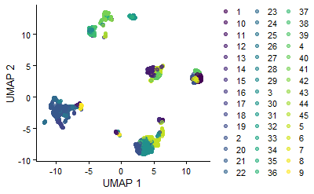

```r
library(bluster)
hclust.out <- clusterRows(mat, HclustParam())
plotUMAP(sce, colour_by=I(hclust.out))
```

Advanced users can achieve greater control of the procedure by passing more parameters to the HclustParam() constructor. Here, we use Ward’s criterion for the agglomeration with a dynamic tree cut from the dynamicTreeCut package.

```r
hp2 <- HclustParam(method="ward.D2", cut.dynamic=TRUE)
hp2
```

```
class: HclustParam
metric: euclidean
method: ward.D2
cut.fun: cutreeDynamic
cut.params(0):
```

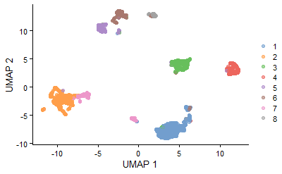

```r
hclust.out <- clusterRows(mat, hp2)
plotUMAP(sce, colour_by=I(hclust.out))
```

# k -means clustering

Our next algorithm is k-means clustering, as implemented using the kmeans() function. This requires us to pass in the number of clusters, either as a number:

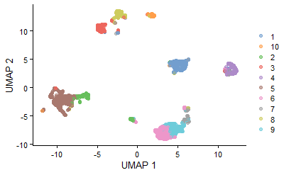

```r
set.seed(100)
kmeans.out <- clusterRows(mat, KmeansParam(10))
plotUMAP(sce, colour_by=I(kmeans.out))
```

Or as a function of the number of observations, which is useful for vector quantization purposes:

```r
kp <- KmeansParam(sqrt)
kp
```

```
class: KmeansParam
centers: variable
extra.args(0):
```

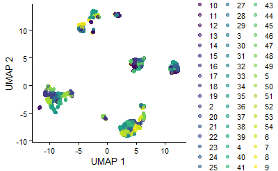

```r
set.seed(100)
kmeans.out <- clusterRows(mat, kp)
plotUMAP(sce, colour_by=I(kmeans.out))
```

# Graph-based clustering

We can build shared or direct nearest neighbor graphs and perform community detection with igraph. Here, the number of neighbors k controls the resolution of the clusters.

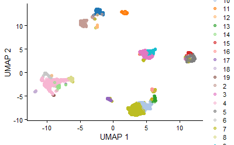

```r
set.seed(101) # just in case there are ties.
graph.out <- clusterRows(mat, NNGraphParam(k=10))
plotUMAP(sce, colour_by=I(graph.out))
```

It is again straightforward to tune the procedure by passing more arguments such as the community detection algorithm to use.

```r
set.seed(101) # just in case there are ties.
np <- NNGraphParam(k=20, cluster.fun="louvain")
np
```

```
class: NNGraphParam
shared: TRUE
graph.args(1): k
cluster.fun: louvain
cluster.args(0):
```

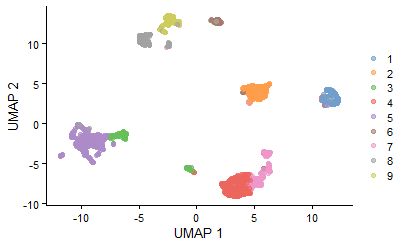

```r
graph.out <- clusterRows(mat, np)
plotUMAP(sce, colour_by=I(graph.out))
```

# Two-phase clustering

We also provide a wrapper for a hybrid “two-step” approach for handling larger datasets. Here, a fast agglomeration is performed with k-means to compact the data, followed by a slower graph-based clustering step to obtain interpretable meta-clusters. (This dataset is not, by and large, big enough for this approach to work particularly well.)

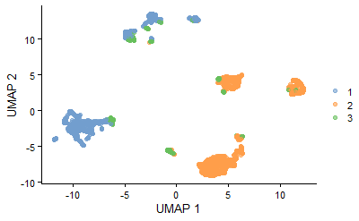

```r
set.seed(100) # for the k-means
two.out <- clusterRows(mat, TwoStepParam())
plotUMAP(sce, colour_by=I(two.out))
```

Each step is itself parametrized by BlusterParam objects, so it is possible to tune them individually:

```r
twop <- TwoStepParam(second=NNGraphParam(k=5))
twop
```

```
class: TwoStepParam
first:
  class: KmeansParam
  centers: variable
  extra.args(0):
second:
  class: NNGraphParam
  shared: TRUE
  graph.args(1): k
  cluster.fun: walktrap
  cluster.args(0):
```

[figure not shown]

```r
set.seed(100) # for the k-means
two.out <- clusterRows(mat, TwoStepParam())
plotUMAP(sce, colour_by=I(two.out))
```

# Obtaining full clustering statistics

Sometimes the vector of cluster assignments is not enough. We can obtain more information about the clustering procedure by setting full=TRUE in clusterRows(). For example, we could obtain the actual graph generated by NNGraphParam():

```r
nn.out <- clusterRows(mat, NNGraphParam(), full=TRUE)
nn.out$objects$graph
```

```
IGRAPH bbd10e2 U-W- 3005 87028 --
+ attr: weight (e/n)
+ edges from bbd10e2:
 [1] 1--  2 1--  3 1--  4 1--  5
 [5] 1--  6 1--  7 1--  8 1--  9
 [9] 1-- 10 1-- 11 1-- 46 1-- 48
[13] 1-- 49 1-- 54 1-- 55 1-- 56
[17] 1-- 59 1-- 61 1-- 63 1-- 64
[21] 1-- 65 1-- 67 1-- 68 1-- 69
[25] 1-- 71 1-- 72 1-- 73 1--157
[29] 1--161 1--164 1--201 1--202
+ ... omitted several edges
```

The assignment vector is still reported in the clusters entry:

```r
table(nn.out$clusters)
```

```
  1   2   3   4   5   6   7   8   9
166 216 256 543 218  89 583  92 123
 10  11  12  13  14  15  16  17  18
186  91  42  94  64  58  58  60  35
 19
 31
```

# Further comments

clusterRows() enables users or developers to easily switch between clustering algorithms by changing a single argument. Indeed, by passing the BlusterParam object across functions, we can ensure that the same algorithm is used through a workflow. It is also helpful for package functions as it provides diverse functionality without compromising a clean function signature. However, the true power of this framework lies in its extensibility. Anyone can write a clusterRows() method for a new clustering algorithm with an associated BlusterParam subclass, and that procedure is immediately compatible with any workflow or function that was already using clusterRows().